# Gene Enrichment Report

Ehsan Zangene

2025-11-19

## 1 1. Load Required Libraries

```r
library(readxl)
library(clusterProfiler)
library(org.Hs.eg.db)
library(org.Ce.eg.db)
library(enrichplot)
library(ReactomePA)
library(ggplot2)
library(dplyr)
library(ggplot2)
library(dplyr)
library(forcats)
```

## 2 2. Input Gene Lists

### 2.1 2.2 Worm Genes

```r
file_path_worm <- "./06-2024/List of verified genes.xlsx"
worm_df <- read_excel(file_path_worm)
wb_col <- grep("WormBase Gene", colnames(worm_df), ignore.case = TRUE, value = TRUE)
worm_df <- worm_df %>% rename(GeneID = all_of(wb_col))
worm_map <- bitr(worm_df$GeneID, fromType = "WORMBASE", toType = "ENTREZID", OrgDb = org.Ce.eg.db)
worm_entrez <- unique(worm_map$ENTREZID)
```

## 3 3. Enrichment Analysis

### 3.1 3.4 C. elegans GO: Biological Process

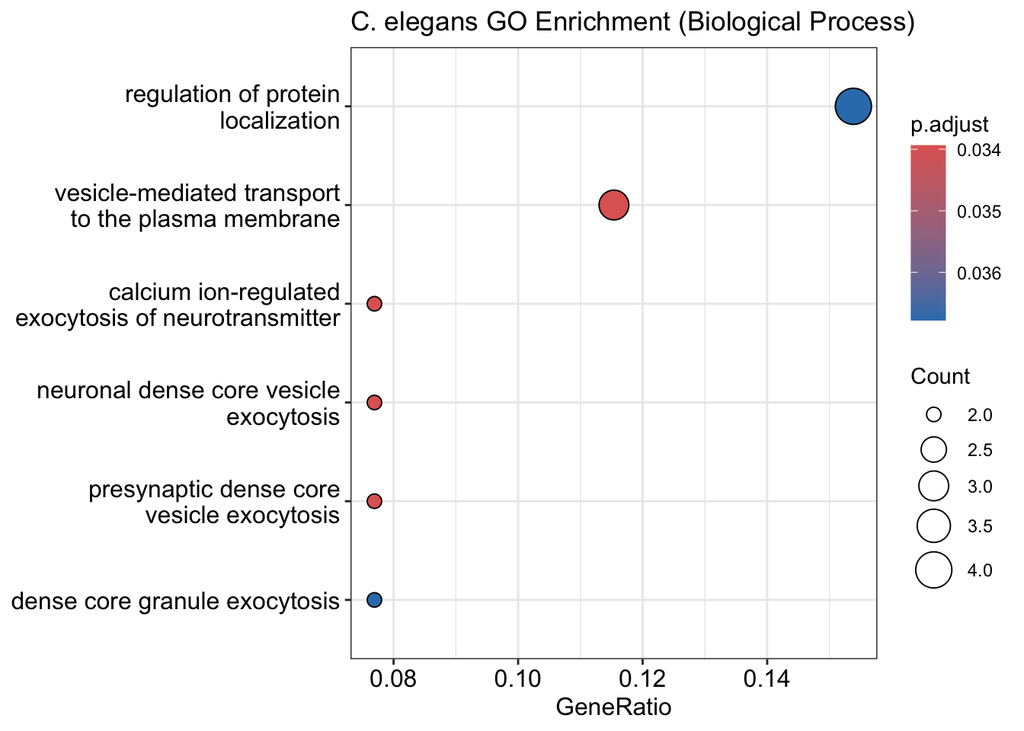

```r
ego_ce_bp <- enrichGO(gene = worm_entrez, OrgDb = org.Ce.eg.db, keyType = "ENTREZID",
                      ont = "BP", pAdjustMethod = "BH", pvalueCutoff = 0.05,
                      qvalueCutoff = 0.2, readable = TRUE)
dotplot(ego_ce_bp, showCategory = 20) + ggtitle("C. elegans GO Enrichment (Biological Process)")
```

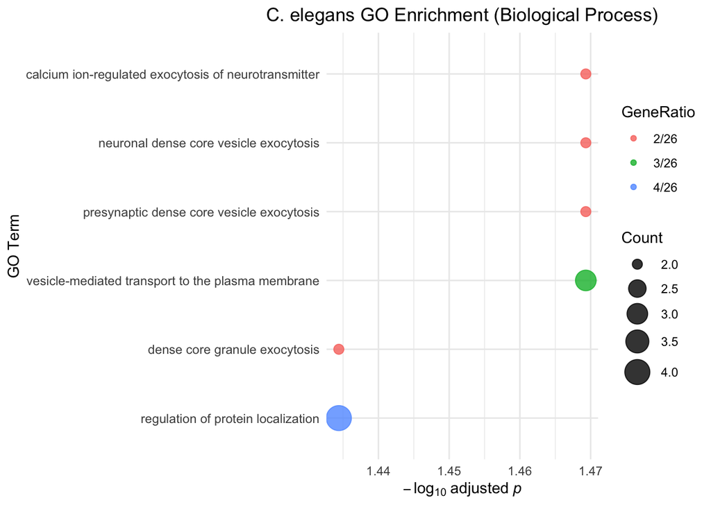

```r
# Extract top 20 results ordered by adjusted p-value
# plot_data <- ego_ce_bp@result %>%
#   arrange(p.adjust) %>%
#   slice(1:6) %>%
#   mutate(Description = fct_reorder(Description, -p.adjust)) %>%
#   mutate(log10_padj = -log10(p.adjust))

# Create custom dot plot
# Step 1: Extract and modify the plot data
plot_data <- ego_ce_bp@result %>%
  arrange(p.adjust) %>%
  slice(1:6) %>%
  mutate(log10_padj = -log10(p.adjust))

# Step 2: Manually define your desired order for y-axis
custom_order <- c(
  "calcium ion-regulated exocytosis of neurotransmitter",
  "neuronal dense core vesicle exocytosis",
  "presynaptic dense core vesicle exocytosis",
  "vesicle-mediated transport to the plasma membrane",
  "dense core granule exocytosis",
  "regulation of protein localization"
)

# Step 3: Convert Description to factor with custom levels
plot_data <- plot_data %>%
  filter(Description %in% custom_order) %>%
  mutate(Description = factor(Description, levels = rev(custom_order)))  # reverse for top-to-bottom

# Step 4: Plot
dotplot_2nd <- ggplot(plot_data, aes(x = log10_padj, y = Description)) +
  geom_point(aes(size = Count, color = GeneRatio), alpha = 0.8) +
  # scale_color_gradient(low = "lightblue", high = "darkblue", name = "GeneRatio") +
  scale_size(range = c(3, 8)) +
  labs(
    x = expression(-log[10]~adjusted~italic(p)),
    y = "GO Term",
    title = "C. elegans GO Enrichment (Biological Process)"
  ) +
  theme_minimal(base_size = 11) +
  theme(
    axis.text.y = element_text(size = 9),
    plot.title = element_text(hjust = 0.5)
  )
dotplot_2nd
```

```r
ggsave("./output_plots/dotplot_2nd_C.e.Biological_Process.pdf", dotplot_2nd, dpi = 600)
```

[figure not shown]

```r
ego_ce_cc <- enrichGO(gene = worm_entrez, OrgDb = org.Ce.eg.db, keyType = "ENTREZID",
                      ont = "CC", pAdjustMethod = "BH", pvalueCutoff = 0.05,
                      qvalueCutoff = 0.2, readable = TRUE)
dotplot(ego_ce_cc, showCategory = 20) + ggtitle("C. elegans GO Enrichment (Biological Process)")
```

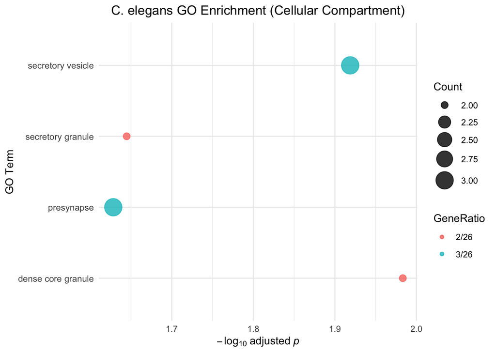

```r
plot_data <- ego_ce_cc@result %>%
  arrange(p.adjust) %>%
  slice(1:4) %>%
  mutate(log10_padj = -log10(p.adjust))

# Step 2: Manually define your desired order for y-axis
# not asked in this case

# Step 3: Convert Description to factor with custom levels
# plot_data <- plot_data %>%
#   filter(Description %in% custom_order) %>%
#   mutate(Description = factor(Description, levels = rev(custom_order)))  # reverse for top-to-bottom

# Step 4: Plot
dotplotCC_2nd <- ggplot(plot_data, aes(x = log10_padj, y = Description)) +
  geom_point(aes(size = Count, color = GeneRatio), alpha = 0.8) +
  # scale_color_gradient(low = "lightblue", high = "darkblue", name = "GeneRatio") +
  scale_size(range = c(3, 8)) +
  labs(
    x = expression(-log[10]~adjusted~italic(p)),
    y = "GO Term",
    title = "C. elegans GO Enrichment (Cellular Compartment)"
  ) +
  theme_minimal(base_size = 11) +
  theme(
    axis.text.y = element_text(size = 9),
    plot.title = element_text(hjust = 0.5)
  )

dotplotCC_2nd
```

```r
ggsave("./output_plots/dotplot_2nd_C.e.Cellular_Compartment.pdf", dotplotCC_2nd, dpi = 600)
```

## 4 5. Materials and Methods

### 4.1 Gene List Curation

Two gene sets were curated for functional enrichment analysis. The first consisted of 33 *Caenorhabditis elegans* genes, verified through a targeted RNAi screening and identified by their WormBase Gene IDs.

### 4.2 Functional Annotation and Enrichment Analysis

Functional enrichment analyses were performed using R (v4.3.1) with the `clusterProfiler` (v4.8.1), `org.Hs.eg.db`, `org.Ce.eg.db`, and `ReactomePA` (v1.44.0) Bioconductor packages. WormBase Gene IDs were mapped to Entrez Gene IDs using `bitr()` with the `org.Ce.eg.db` annotation. Similarly, human gene symbols were converted to Entrez IDs using `org.Hs.eg.db`.

KEGG pathway analysis was attempted but yielded no significant enrichments for either species under the set cutoff thresholds.

### 4.3 Visualization

Top enriched categories (up to 20 terms) were visualized using `dotplot()` from the `enrichplot` package. All enrichment terms reported in the figures met a false discovery rate (FDR) threshold of *q* < 0.2.